# Final Project Jenna Reece

### Introduction

Blood product transfusion is a common and lifesaving intervention for patients, but despite its benefits, it also introduces risks for patients, including the risk of transfusion reaction, infectious complications, and alloimmunization. Many studies over the past few decades have demonstrated that transfusion thresholds that are more conservative, i.e. more restrictive, lead to better patient outcomes than liberal transfusion thresholds. I am examining an operational dataset which contains blood products administered to patients, and their hematologic lab values, which will be compared to established transfusion guidelines.

Obviously, there are many complex factors that play into whether a transfusion is indicated, and transfusion thresholds may be personalized for patients, but it will be helpful to describe practices and trends to identify areas for potential intervention. There are several specific questions of particular interest to the blood bank, notably how often clinicians evaluate the corrected count increment after platelet transfusion. Other concerns include the size of the population with certain transfusion thresholds, and identifying practice patterns for particular providers. In general, knowing how blood products are used allows the blood bank to more accurately predict blood needs in the future, which allows for better planning and inventory management.

### Methods

Data cleaning: The data that I have for this project begins in an excel file, which means that I need to do some cleaning to get it in the right format. I will also be using de-identified data, in which MRN is a random ID, and all names and accession numbers have been removed.

R Code:

```r
# Loading the necessary packages for analysis

library(tidyverse)
```

```r
library(readxl)
library(dplyr)
library(ggplot2)
library(stringr)
library(knitr)
library(lubridate)
library(scales)
# Loading the data and cleaning it
# The first two lines of the file are header lines.

suppressWarnings({
df1 <- read_excel("Blood Bank Transfusion_1.xlsx", skip=2)
df2 <- read_excel("Blood Bank Transfusion_2.xlsx", skip = 2)
df3 <- read_excel("Blood Bank Transfusion_3.xlsx", skip = 2)
df4 <- read_excel("Blood Bank Transfusion_4.xlsx", skip = 2)
df5 <- read_excel("Blood Bank Transfusion_5.xlsx", skip=2)
df6 <- read_excel("Blood Bank Transfusion_6.xlsx", skip = 2)
df7 <- read_excel("Blood Bank Transfusion_7.xlsx", skip = 2)
df8 <- read_excel("Blood Bank Transfusion_8.xlsx", skip = 2)
df9 <- read_excel("Blood Bank Transfusion_9.xlsx", skip=2)
df10 <- read_excel("Blood Bank Transfusion_10.xlsx", skip = 2)
df11 <- read_excel("Blood Bank Transfusion_11.xlsx", skip = 2)
df12 <- read_excel("Blood Bank Transfusion_12.xlsx", skip = 2)
df13 <- read_excel("Blood Bank Transfusion_13.xlsx", skip=2)
df14 <- read_excel("Blood Bank Transfusion_14.xlsx", skip = 2)
df15 <- read_excel("Blood Bank Transfusion_15.xlsx", skip = 2)
df16 <- read_excel("Blood Bank Transfusion_16.xlsx", skip = 2)
df17 <- read_excel("Blood Bank Transfusion_17.xlsx", skip=2)
df18 <- read_excel("Blood Bank Transfusion_18.xlsx", skip = 2)
df19 <- read_excel("Blood Bank Transfusion_19.xlsx", skip = 2)
df20 <- read_excel("Blood Bank Transfusion_20.xlsx", skip = 2)
df21 <- read_excel("Blood Bank Transfusion_21.xlsx", skip=2)
df22 <- read_excel("Blood Bank Transfusion_22.xlsx", skip = 2)
df23 <- read_excel("Blood Bank Transfusion_23.xlsx", skip = 2)
df24 <- read_excel("Blood Bank Transfusion_24.xlsx", skip = 2)
df25 <- read_excel("Blood Bank Transfusion_25.xlsx", skip=2)
df26 <- read_excel("Blood Bank Transfusion_26.xlsx", skip = 2)
df27 <- read_excel("Blood Bank Transfusion_27.xlsx", skip = 2)
df28 <- read_excel("Blood Bank Transfusion_28.xlsx", skip = 2)
df29 <- read_excel("Blood Bank Transfusion_29.xlsx", skip=2)
df30 <- read_excel("Blood Bank Transfusion_30.xlsx", skip = 2)
df31 <- read_excel("Blood Bank Transfusion_31.xlsx", skip = 2)
df32 <- read_excel("Blood Bank Transfusion_32.xlsx", skip = 2)
df33 <- read_excel("Blood Bank Transfusion_33.xlsx", skip=2)
df34 <- read_excel("Blood Bank Transfusion_34.xlsx", skip = 2)
df35 <- read_excel("Blood Bank Transfusion_35.xlsx", skip = 2)
df36 <- read_excel("Blood Bank Transfusion_36.xlsx", skip = 2)
df37 <- read_excel("Blood Bank Transfusion_37.xlsx", skip=2)
df38 <- read_excel("Blood Bank Transfusion_38.xlsx", skip = 2)
df39 <- read_excel("Blood Bank Transfusion_39.xlsx", skip = 2)
})
```

```r
# Each dataset is for a single week somewhere between 2020 and 2021. This is to combine these datasets into a single dataset.

joineddf<-rbind(df1,df2,df3,df4,df5, df6, df7, df8, df9, df10, df11, df12, df13, df14, df15, df16, df17, df18, df19, df20, df21, df22, df23, df24, df25, df26, df27, df28, df29, df30, df31, df32, df33, df34, df35, df36, df37, df38, df39)
```

```r
# Creates a dataframe for Red blood cell transfusions only, that includes only one row per Red blood cell transfusion.

df_RBCTransfusion <- joineddf %>% filter(PRODUCT_TYPE == "Red Cells") %>% select(MRN, TRANSFUSION_DATE, PRODUCT_TYPE) %>% unique(by =c(MRN, TRANSFUSION_DATE, PRODUCT_TYPE))
```

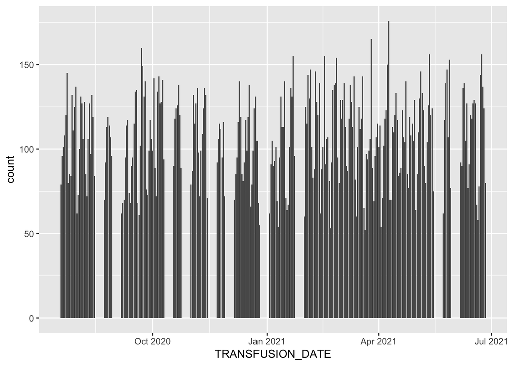

```r
#Determining whether I have complete data, and which dates I have available. I am missing 10 weeks of data, but I have 39 weeks in total. I wish to identify the ideal unbroken interval to use.
df_RBCTransfusion$TRANSFUSION_DATE<-as.Date(df_RBCTransfusion$TRANSFUSION_DATE)

ggplot(df_RBCTransfusion, aes(TRANSFUSION_DATE))+
  geom_bar(na.rm=TRUE)
```

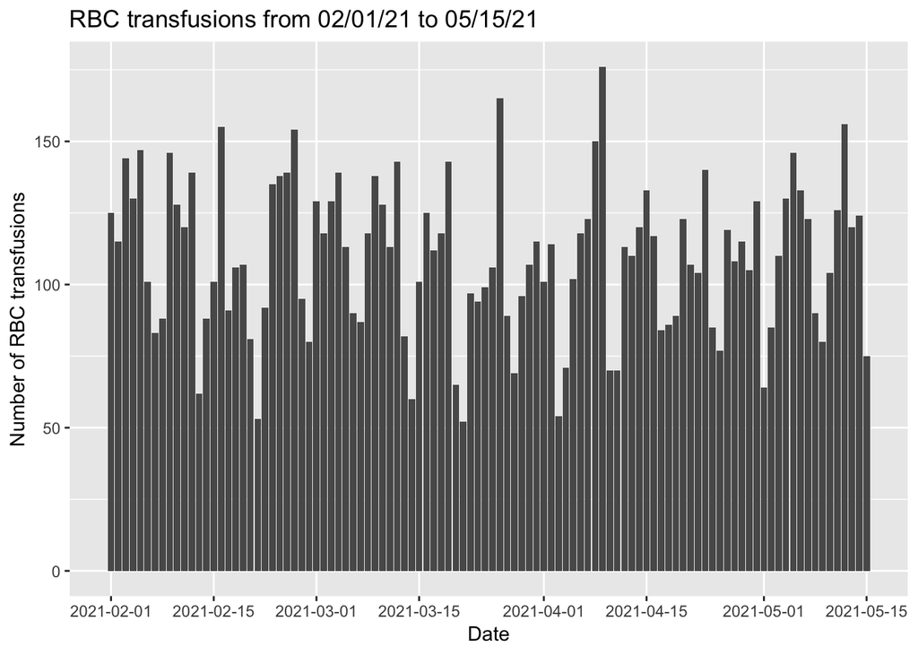

```r
##With this code, I am establishing a smaller dataset that is continuous and does not have any gaps.



UnbrokenRBC<- df_RBCTransfusion %>%
  filter(between(TRANSFUSION_DATE, as.Date('2021-02-01'), as.Date('2021-05-15')))

RBCtransfusionsbydateplot<- ggplot(data=UnbrokenRBC, mapping=aes(x=TRANSFUSION_DATE))+
  geom_bar()+
  scale_x_date(breaks = as.Date(c("2021-02-01", "2021-02-15",
                                        "2021-03-01","2021-03-15",
                                        "2021-04-01","2021-04-15",
                                        "2021-05-01", "2021-05-15")),
               minor_breaks= as.Date(c("2021-02-01", "2021-02-15",
                                        "2021-03-01","2021-03-15",
                                        "2021-04-01","2021-04-15",
                                        "2021-05-01", "2021-05-15"))) +
  labs(x='Date', y="Number of RBC transfusions") +
  ggtitle("RBC transfusions from 02/01/21 to 05/15/21")

RBCtransfusionsbydateplot
```

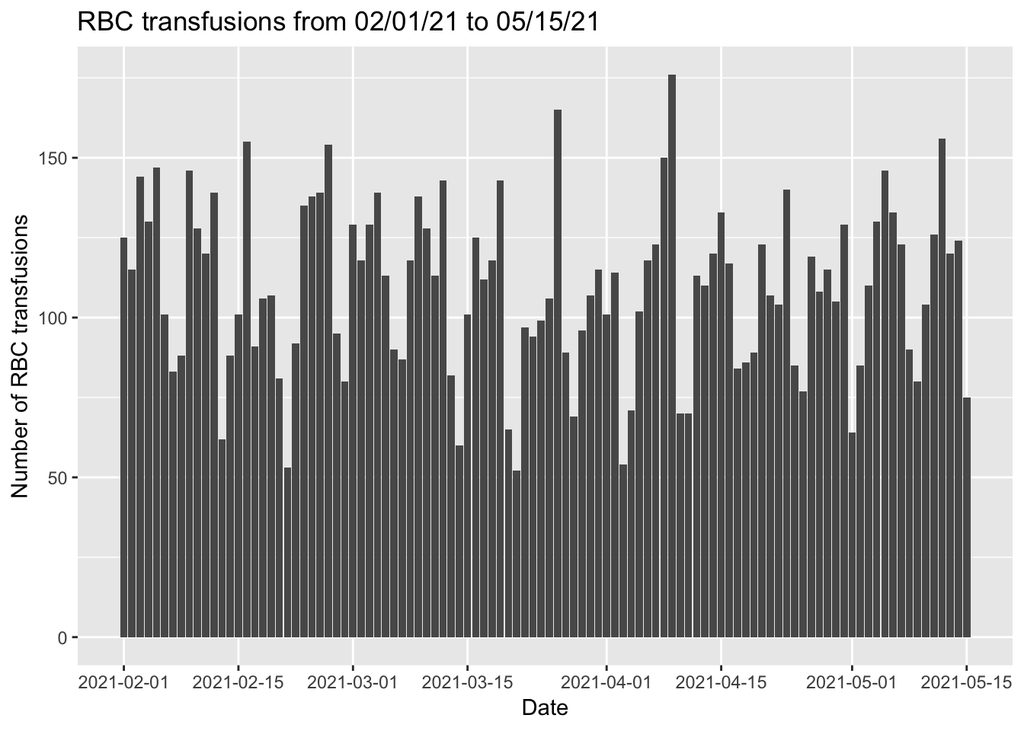

```r
##I am testing the distribution of transfusion counts

UnbrokensmallRBC<- df_RBCTransfusion %>%
  filter(between(TRANSFUSION_DATE, as.Date('2021-02-01'), as.Date('2021-02-15')))

smallRBCtransfusionsbydateplot<- ggplot(data=UnbrokenRBC, mapping=aes(x=TRANSFUSION_DATE))+
  geom_bar()+
  scale_x_date(breaks = as.Date(c("2021-02-01", "2021-02-03",
                                    "2021-02-05", "2021-02-07",
                                        "2021-02-09","2021-02-11",
                                        "2021-02-13", "2021-02-15")),
               minor_breaks = as.Date(c( "2021-02-01", "2021-02-03",
                                        "2021-02-05", "2021-02-07",
                                        "2021-02-09","2021-02-11",
                                        "2021-02-13", "2021-02-15"))) +
  labs(x='Date', y="Number of RBC transfusions") +
  ggtitle("RBC transfusions from 02/01/21 to 05/15/21")

RBCtransfusionsbydateplot
```

```r
#Creating a graph of monthly RBC transfusions

UnbrokensansMayRBC<- df_RBCTransfusion %>%
  filter(between(TRANSFUSION_DATE, as.Date('2021-02-01'), as.Date('2021-04-30')))

class(UnbrokensansMayRBC$TRANSFUSION_DATE)
```

```
## [1] "Date"
```

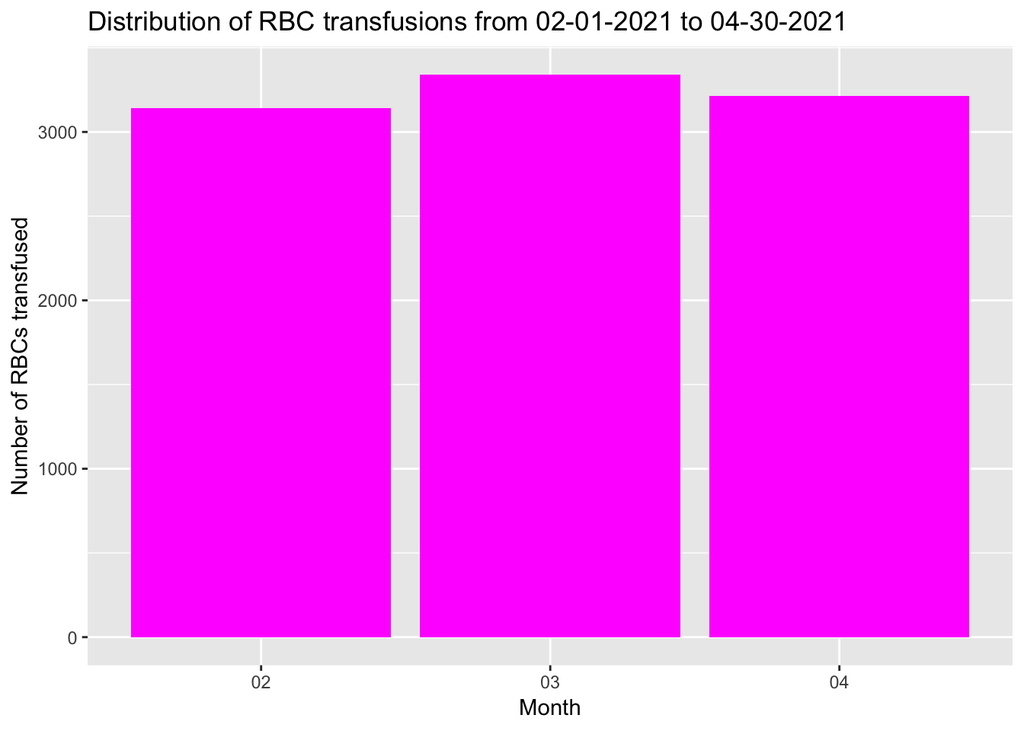

```r
x_month<-format(UnbrokensansMayRBC$TRANSFUSION_DATE, "%m")

monthlyRBCFebmayplot<- ggplot(data=UnbrokensansMayRBC, mapping=aes(x=x_month))+
  geom_bar(fill='magenta')+
  labs(x='Month', y='Number of RBCs transfused')+
  ggtitle("Distribution of RBC transfusions from 02-01-2021 to 04-30-2021")

monthlyRBCFebmayplot
```

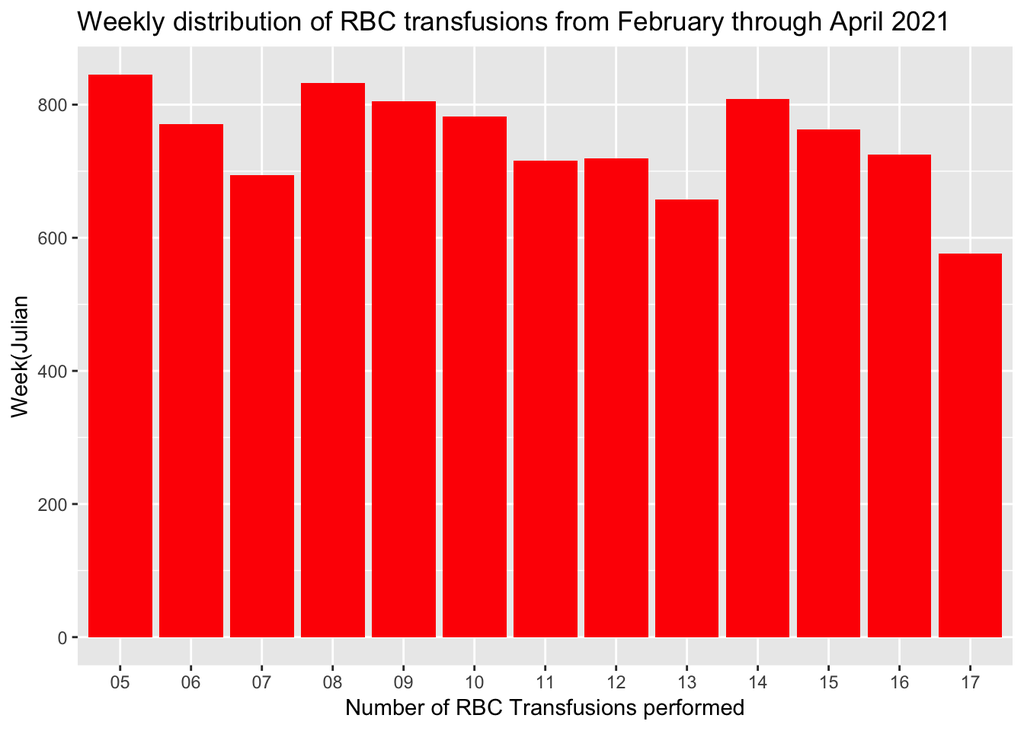

```r
#Creating a graph of weekly RBC transfusions

UnbrokensansMayRBC$week_num <-strftime(UnbrokensansMayRBC$TRANSFUSION_DATE, format= "%V")

weeklyRBCFebmayplot<- ggplot(data= UnbrokensansMayRBC, mapping=aes(x=week_num))+
  geom_bar(fill='red')+
  labs(x='Number of RBC Transfusions performed', y='Week(Julian')+
  ggtitle("Weekly distribution of RBC transfusions from February through April 2021")

weeklyRBCFebmayplot
```

```r
#Now that each row is a transfusion, we will create a dataframe that lists how many RBC transfusions each patient received.

dfRBCtop<-UnbrokenRBC %>%
  count(MRN) %>%
  arrange(desc(n))
```

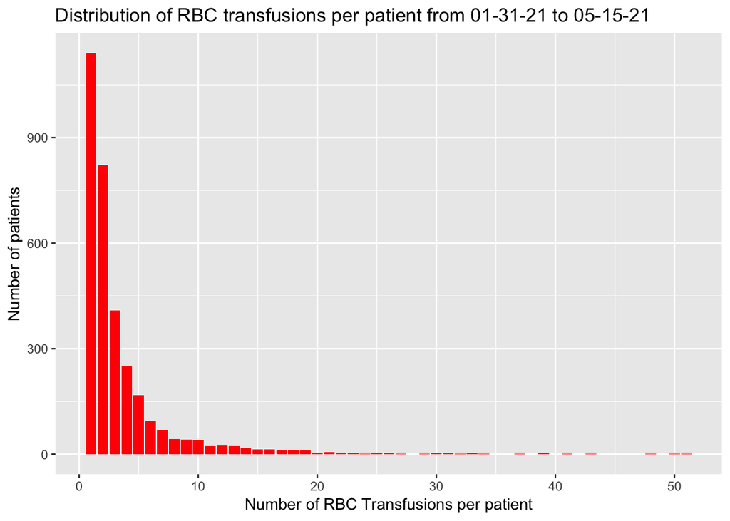

```r
# We will plot this data in a bar chart.

PlotRBCperptdf<- ggplot(data= dfRBCtop, mapping=aes(x=n))+
  geom_bar(fill='red')+
  labs(x='Number of RBC Transfusions per patient', y='Number of patients')+
  ggtitle("Distribution of RBC transfusions per patient from 01-31-21 to 05-15-21")


PlotRBCperptdf
```

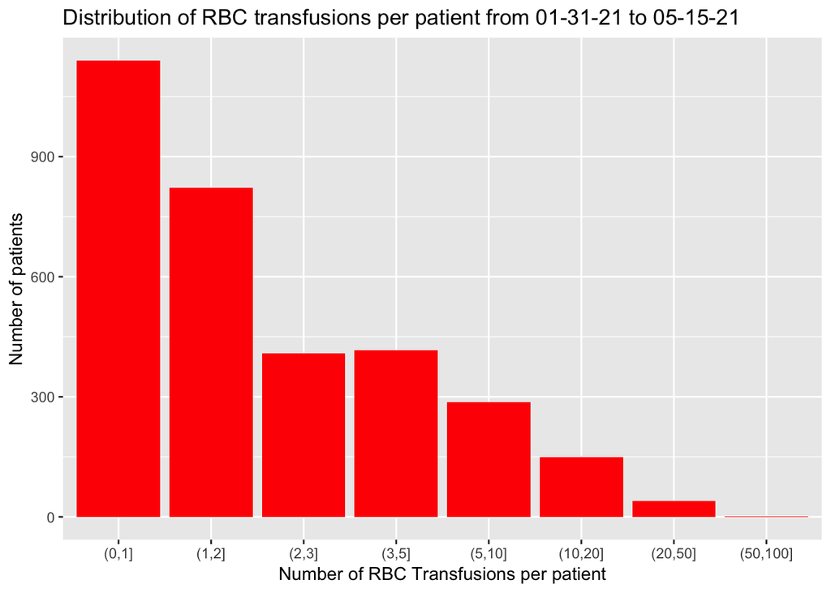

```r
# Other

# PlotRBCperptdf<- ggplot(data= dfRBCtop, mapping=aes(x=n))+
  #geom_bar(fill='red')+
  #labs(x='Number of RBC Transfusions per patient', y='Number of patients')+
  #ggtitle("Distribution of RBC transfusions per patient from 01-31-21 to 05-15-21")


##Establishing a smaller dataset that is continuous and does not have any gaps

RBCtopcountsdiff<- dfRBCtop %>% mutate(transcount_bin= cut(n,breaks=c(0,1,2,3,5,10,20,50,100)))

RBCtopBinnedgraph<- ggplot(data= RBCtopcountsdiff, mapping=aes(x=transcount_bin))+
  geom_bar(fill='red')+
  labs(x='Number of RBC Transfusions per patient', y='Number of patients')+
  ggtitle("Distribution of RBC transfusions per patient from 01-31-21 to 05-15-21")


RBCtopBinnedgraph
```

```r
# I am pulling the hemoglobin results for transfusions that occurred in February to May 15 2021

df_Hgb <- joineddf %>% filter(RESULT_CODE == "Hgb") %>% select(MRN, COLLECT_DATE, RESULT, RESULT_CODE, TRANSFUSION_DATE) %>% unique(by =c(MRN, COLLECT_DATE))

UnbrokenHgb<- df_Hgb %>%
  filter(between(TRANSFUSION_DATE, as.Date('2021-02-01'), as.Date('2021-05-15')))
```

The next steps of analysis include breaking down the hemoglobin by collection time, and comparing it to the transfusion time to be able to compare pre and post hemoglobin values, as well as average pre transfusion hemoglobin, and post-transfusion hemoglobin.

I would then compare whether the pre-transfusion hemoglobin was greater than the recommended <7 in most hemodynamically stable patients. We would expect that some percentage of patients would be transfused above this threshold, because they have cardiac ischemia, or are unstable or have trauma, but it would be useful to get a sense of what proportion of patients fall in this category, and a further chart review could be performed on a subset of patients who did NOT meet criteria, as an audit.

### Conclusions

This analysis was consistent with my anecdotal knowledge that the majority of patients received 1-2 transfusions, but that there are extreme outliers who receive 50 or more units. The overall volume of red blood cell transfusion can very by over a hundred units from one week to the next, but shows less variation from month to month. Given the shelf life of blood, this amount of variation can be planned for.